## *Packages*

```r
library(dLagM)
library(dynlm)
library(MLmetrics)
library(lmtest)
library(car)
```

## Impor Data

```r
data <- rio::import("https://raw.githubusercontent.com/akabanenabaka/mpdw/main/turbin.csv")
str(data)
```

```
## 'data.frame':    114 obs. of  5 variables:
##  $ V1                : POSIXct, format: "2020-03-07 23:40:00" "2020-03-07 23:50:00" ...
##  $ ActivePower       : num  17.56 22.55 37.18 23.97 -5.54 ...
##  $ GeneratorRPM      : num  1030 1030 1030 1030 441 ...
##  $ MainBoxTemperature: num  34.8 34.7 34.6 34.6 34.8 ...
##  $ WindSpeed         : num  3.69 3.37 3.75 3.25 3.27 ...
```

```r
data
```

```
##                      V1  ActivePower GeneratorRPM MainBoxTemperature WindSpeed
## 1   2020-03-07 23:40:00   17.5628248   1030.13354           34.76612  3.692805
## 2   2020-03-07 23:50:00   22.5520368   1030.09076           34.73125  3.368355
## 3   2020-03-08 00:00:00   37.1831815   1029.91624           34.64316  3.753665
## 4   2020-03-08 00:10:00   23.9665754   1030.10776           34.61815  3.245068
## 5   2020-03-08 00:20:00   -5.5399407    440.67113           34.82150  3.274189
## 6   2020-03-08 00:30:00   -5.9297118    107.01361           35.93750  2.646167
## 7   2020-03-08 00:40:00   -6.2656468     83.80418           36.74219  2.298000
## 8   2020-03-08 00:50:00   -6.2104620    134.55668           37.30245  3.078311
## 9   2020-03-08 01:00:00   -6.0702186    795.73657           37.74891  3.324244
## 10  2020-03-08 01:10:00   -6.1634527   1025.40628           38.01452  3.012695
## 11  2020-03-08 01:20:00   -6.1938612    422.44603           38.26420  2.869444
## 12  2020-03-08 01:30:00   -6.0429409    143.27424           38.45536  2.714539
## 13  2020-03-08 01:40:00    9.0243997    473.88694           38.55547  3.375226
## 14  2020-03-08 01:50:00   36.1795006   1029.69282           36.68028  3.342541
```

[output cut: 100 more lines]

## Pembagian Data

```r
#SPLIT DATA
train<-data[1:91,]
test<-data[92:114,]
```

```r
#data time series
train.ts<-ts(train)
test.ts<-ts(test)
data.ts<-ts(data)
```

## Model Koyck

$$y_t=a(1-\lambda)+\beta_0X_t+\beta_1Z_t+\lambda Y_{t-1}+V_t$$

dengan
$$V_t=u_t-\lambda
u_{t-1}$$

### Pemodelan

```r
#MODEL KOYCK
model.koyck <- koyckDlm(x = train$WindSpeed, y = train$GeneratorRPM)
summary(model.koyck)
```

```
##
## Call:
## "Y ~ (Intercept) + Y.1 + X.t"
##
## Residuals:
##      Min       1Q   Median       3Q      Max
## -569.330  -97.110    1.753  168.256  568.971
##
## Coefficients:
##              Estimate Std. Error t value Pr(>|t|)
## (Intercept) -77.86517   75.62532  -1.030  0.30604
## Y.1           0.32056    0.09634   3.327  0.00129 **
## X.t         150.84428   26.48612   5.695 1.64e-07 ***
## ---
## Signif. codes:  0 '***' 0.001 '**' 0.01 '*' 0.05 '.' 0.1 ' ' 1
##
## Residual standard error: 245.9 on 87 degrees of freedom
## Multiple R-Squared: 0.7503,  Adjusted R-squared: 0.7446
## Wald test: 118.7 on 2 and 87 DF,  p-value: < 2.2e-16
##
## Diagnostic tests:
## NULL
##
##                              alpha     beta       phi
## Geometric coefficients:  -114.6015 150.8443 0.3205575
```

```r
AIC(model.koyck)
```

```
## [1] 1251.245
```

```r
BIC(model.koyck)
```

```
## [1] 1261.244
```

Dari hasil tersebut, didapat bahwa peubah $x_t$ dan $y_{t-1}$ memiliki nilai $P-Value<0.05$. Hal ini menunjukkan bahwa peubah $x_t$ dan $y_{t-1}$ berpengaruh signifikan terhadap $y$. Adapun model keseluruhannya adalah sebagai berikut

$$\hat{Y_t}=-77.86517+150.84428X_t+0.32056Y_{t-1}$$

### Peramalan dan Akurasi

Berikut adalah hasil peramalan y untuk 23 periode kedepan menggunakan model koyck

```r
fore.koyck <- forecast(model = model.koyck, x=test$WindSpeed, h=23)
fore.koyck
```

```
## $forecasts
##  [1] 1681.824 1699.994 1614.881 1711.019 1808.214 1765.173 1630.388 1814.054
##  [9] 1745.691 1611.404 1615.585 1569.323 1591.213 1566.406 1523.201 1592.705
## [17] 1542.187 1546.469 1686.003 1676.177 1746.067 1759.719 1664.433
##
## $call
## forecast.koyckDlm(model = model.koyck, x = test$WindSpeed, h = 23)
##
## attr(,"class")
## [1] "forecast.koyckDlm" "dLagM"
```

```r
mape.koyck <- MAPE(fore.koyck$forecasts, test$GeneratorRPM)
#akurasi data training
GoF(model.koyck)
```

```
##              n      MAE        MPE      MAPE     sMAPE      MASE      MSE
## model.koyck 90 183.6917 -0.6528795 0.8370518 0.3614392 0.8284207 58451.58
##                 MRAE    GMRAE
## model.koyck 38.77025 1.187892
```

## Regression with Distributed Lag

### Pemodelan (Lag=2)

```r
model.dlm <- dlm(x = train$WindSpeed,y = train$GeneratorRPM, q = 2)
summary(model.dlm)
```

```
##
## Call:
## lm(formula = model.formula, data = design)
##
## Residuals:
##     Min      1Q  Median      3Q     Max
## -556.61 -128.60   -2.17  194.83  464.09
##
## Coefficients:
##             Estimate Std. Error t value Pr(>|t|)
## (Intercept)  -117.61      72.66  -1.619  0.10921
## x.t           263.87      46.62   5.660 2.01e-07 ***
## x.1            85.30      52.70   1.619  0.10921
## x.2          -129.81      47.28  -2.746  0.00737 **
## ---
## Signif. codes:  0 '***' 0.001 '**' 0.01 '*' 0.05 '.' 0.1 ' ' 1
##
## Residual standard error: 245.4 on 85 degrees of freedom
## Multiple R-squared:  0.757,  Adjusted R-squared:  0.7484
## F-statistic: 88.27 on 3 and 85 DF,  p-value: < 2.2e-16
##
## AIC and BIC values for the model:
##        AIC      BIC
## 1 1237.963 1250.406
```

```r
AIC(model.dlm)
```

```
## [1] 1237.963
```

```r
BIC(model.dlm)
```

```
## [1] 1250.406
```

Dari hasil diatas, didapat bahwa $x_t$ dari intercept dan $x_{t-2}<0.05$. Hal ini menunjukkan bahwa $x_t$ dan $x_{t-2}$ berpengaruh signifikan terhadap $y$. Adapun model keseluruhan yang terbentuk adalah sebagai berikut

$$\hat{Y_t}=-117.61+263.87X_t+85.30X_{t-1}-129.81X_{t-2}$$

### Peramalan dan Akurasi

Berikut merupakan hasil peramalan $y$ untuk 23 periode kedepan

```r
fore.dlm <- forecast(model = model.dlm, x=test$WindSpeed, h=23)
fore.dlm
```

```
## $forecasts
##  [1] 1760.919 1727.105 1509.425 1689.199 1953.364 1754.895 1444.172 1836.472
##  [9] 1846.308 1382.544 1511.109 1551.251 1547.921 1553.980 1442.718 1595.979
## [17] 1546.106 1469.027 1784.939 1750.015 1728.037 1800.979 1558.837
##
## $call
## forecast.dlm(model = model.dlm, x = test$WindSpeed, h = 23)
##
## attr(,"class")
## [1] "forecast.dlm" "dLagM"
```

```r
mape.dlm <- MAPE(fore.dlm$forecasts, test$GeneratorRPM)
#akurasi data training
GoF(model.dlm)
```

```
##            n      MAE        MPE      MAPE     sMAPE      MASE      MSE
## model.dlm 89 193.8752 -0.6130253 0.8069997 0.3684793 0.8645302 57495.45
##               MRAE    GMRAE
## model.dlm 37.31434 1.464512
```

### *Lag* Optimum

```r
#penentuan lag optimum
finiteDLMauto(formula = GeneratorRPM ~ WindSpeed,
              data = data.frame(train), q.min = 1, q.max = 6,
              model.type = "dlm", error.type = "AIC", trace = FALSE)
```

```
##   q - k    MASE      AIC      BIC   GMRAE   MBRAE R.Adj.Sq   Ljung-Box
## 6     6 0.83631 1182.137 1204.121 1.37699 0.85645  0.76075 0.005606611
```

Berdasarkan output tersebut, lag optimum didapatkan ketika lag=6. Selanjutnya dilakukan pemodelan untuk lag=6

```r
#model dlm dengan lag optimum
model.dlm2 <- dlm(x = train$WindSpeed,y = train$GeneratorRPM , q = 6)
summary(model.dlm2)
```

```
##
## Call:
## lm(formula = model.formula, data = design)
##
## Residuals:
##    Min     1Q Median     3Q    Max
## -521.6 -133.0    6.1  154.4  415.2
##
## Coefficients:
##             Estimate Std. Error t value Pr(>|t|)
## (Intercept)   -92.61      75.03  -1.234    0.221
## x.t           275.14      51.38   5.355 8.59e-07 ***
## x.1           131.41      56.23   2.337    0.022 *
## x.2           -89.00      54.32  -1.638    0.105
## x.3           -19.72      56.52  -0.349    0.728
## x.4           -71.46      54.56  -1.310    0.194
## x.5            42.77      57.39   0.745    0.458
## x.6           -59.96      52.24  -1.148    0.255
## ---
## Signif. codes:  0 '***' 0.001 '**' 0.01 '*' 0.05 '.' 0.1 ' ' 1
##
## Residual standard error: 239.5 on 77 degrees of freedom
## Multiple R-squared:  0.7807, Adjusted R-squared:  0.7608
## F-statistic: 39.16 on 7 and 77 DF,  p-value: < 2.2e-16
##
## AIC and BIC values for the model:
##        AIC      BIC
## 1 1182.137 1204.121
```

```r
AIC(model.dlm2)
```

```
## [1] 1182.137
```

```r
BIC(model.dlm2)
```

```
## [1] 1204.121
```

Dari hasil tersebut terdapat beberapa peubah yang berpengaruh signifikan terhadap taraf nyata 5% yaitu $x_t$ dan $x_{t-1}$. Adapun keseluruhan model yang terbentuk adalah

$$\hat{Y_t}=-92.61+275.14X_t+...-59.96X_{t-6}$$

Adapun hasil peramalan 23 periode kedepan menggunakan model tersebut adalah sebagai berikut

```r
#peramalan dan akurasi
fore.dlm2 <- forecast(model = model.dlm2, x=test$WindSpeed, h=23)
mape.dlm2<- MAPE(fore.dlm2$forecasts, test$GeneratorRPM)
#akurasi data training
GoF(model.dlm2)
```

```
##             n      MAE        MPE      MAPE     sMAPE      MASE      MSE
## model.dlm2 85 187.0545 -0.5585758 0.7448094 0.3503716 0.8363116 51940.62
##                MRAE    GMRAE
## model.dlm2 15.41937 1.376995
```

Model tersebut merupakan model yang buruk dengan nilai MAPE yang lebih dari 50%.

## Model Autoregressive

### Pemodelan

```r
model.ardl <- ardlDlm(x = train$WindSpeed, y = train$GeneratorRPM, p = 1 , q = 1)
summary(model.ardl)
```

```
##
## Time series regression with "ts" data:
## Start = 2, End = 91
##
## Call:
## dynlm(formula = as.formula(model.text), data = data, start = 1)
##
## Residuals:
##     Min      1Q  Median      3Q     Max
## -585.40 -141.42    0.47  160.23  551.92
##
## Coefficients:
##             Estimate Std. Error t value Pr(>|t|)
## (Intercept) -92.8675    71.8627  -1.292  0.19972
## X.t         229.4416    43.3666   5.291 9.17e-07 ***
## X.1         -79.9735    51.5248  -1.552  0.12430
## Y.1           0.3398     0.1010   3.364  0.00115 **
## ---
## Signif. codes:  0 '***' 0.001 '**' 0.01 '*' 0.05 '.' 0.1 ' ' 1
##
## Residual standard error: 242.7 on 86 degrees of freedom
## Multiple R-squared:  0.7595, Adjusted R-squared:  0.7511
## F-statistic: 90.54 on 3 and 86 DF,  p-value: < 2.2e-16
```

```r
AIC(model.ardl)
```

```
## [1] 1249.871
```

```r
BIC(model.ardl)
```

```
## [1] 1262.37
```

Hasil di atas menunjukkan bahwa selain peubah $x_{t-1}$, hasil uji t menunjukkan nilai-p pada peubah $<0.05$. Hal ini menunjukkan bahwa peubah $x_t$ dan $y_{t-1}$ berpengaruh signifikan terhadap $y_t$. Model keseluruhannya adalah sebagai berikut:

$$\hat{Y}=-92.8675+229.4416X_t-79.9735X_{t-1}+0.3398Y_{t-1}$$

### Peramalan dan Akurasi

```r
fore.ardl <- forecast(model = model.ardl, x=test$WindSpeed, h=23)
fore.ardl
```

```
## $forecasts
##  [1] 1715.547 1708.166 1576.763 1768.049 1868.586 1754.702 1571.309 1918.212
##  [9] 1722.288 1552.237 1625.860 1553.435 1609.911 1561.231 1507.939 1635.302
## [17] 1523.664 1555.466 1765.568 1680.740 1791.933 1777.686 1625.893
##
## $call
## forecast.ardlDlm(model = model.ardl, x = test$WindSpeed, h = 23)
##
## attr(,"class")
## [1] "forecast.ardlDlm" "dLagM"
```

Data di atas merupakan hasil peramalan untuk 23 periode ke depan menggunakan Model Autoregressive dengan $p=1$ dan $q=1$.

```r
mape.ardl <- MAPE(fore.ardl$forecasts, test$GeneratorRPM)
mape.ardl
```

```
## [1] 0.03700904
```

```r
#akurasi data training
GoF(model.ardl)
```

```
##             n     MAE        MPE      MAPE     sMAPE      MASE      MSE
## model.ardl 90 180.398 -0.6075734 0.7907888 0.3564428 0.8135664 56301.15
##                MRAE    GMRAE
## model.ardl 38.28685 1.270794
```

Berdasarkan akurasi di atas, terlihat bahwa nilai MAPE keduanya cukup berbeda.

### *Lag* Optimum

```r
#penentuan lag optimum
model.ardl.opt <- ardlBoundOrders(data = data.frame(data), ic = "AIC",
                                  formula = GeneratorRPM ~ WindSpeed )
min_p=c()
for(i in 1:6){
  min_p[i]=min(model.ardl.opt$Stat.table[[i]])
}
q_opt=which(min_p==min(min_p, na.rm = TRUE))
p_opt=which(model.ardl.opt$Stat.table[[q_opt]] ==
              min(model.ardl.opt$Stat.table[[q_opt]], na.rm = TRUE))
data.frame("q_optimum" = q_opt, "p_optimum" = p_opt,
           "AIC"=model.ardl.opt$min.Stat)
```

```
##   q_optimum p_optimum      AIC
## 1         1        15 1336.308
```

Dari tabel di atas, dapat terlihat bahwa nilai AIC terendah didapat ketika $p=15$ dan $q=1$, yaitu sebesar `1336.308`. Artinya, model autoregressive optimum didapat ketika $p=15$ dan $q=1$.

## Pemodelan DLM & ARDL dengan Library `dynlm`

```r
#sama dengan model dlm q=1
cons_lm1 <- dynlm(GeneratorRPM ~ WindSpeed+L(WindSpeed),data = train.ts)
#sama dengan model ardl p=1 q=0
cons_lm2 <- dynlm(GeneratorRPM ~ WindSpeed+L(GeneratorRPM),data = train.ts)
#sama dengan ardl p=1 q=1
cons_lm3 <- dynlm(GeneratorRPM ~ WindSpeed+L(WindSpeed)+L(GeneratorRPM),data = train.ts)
#sama dengan dlm p=2
cons_lm4 <- dynlm(GeneratorRPM ~ WindSpeed+L(WindSpeed)+L(WindSpeed,2),data = train.ts)
```

### Ringkasan Model

```r
summary(cons_lm1)
```

```
##
## Time series regression with "ts" data:
## Start = 2, End = 91
##
## Call:
## dynlm(formula = GeneratorRPM ~ WindSpeed + L(WindSpeed), data = train.ts)
##
## Residuals:
##    Min     1Q Median     3Q    Max
## -531.6 -111.0   -4.5  180.7  475.2
##
## Coefficients:
##              Estimate Std. Error t value Pr(>|t|)
## (Intercept)   -131.41      75.03  -1.751   0.0834 .
## WindSpeed      214.08      45.61   4.694 9.92e-06 ***
## L(WindSpeed)    11.04      46.38   0.238   0.8125
## ---
## Signif. codes:  0 '***' 0.001 '**' 0.01 '*' 0.05 '.' 0.1 ' ' 1
##
## Residual standard error: 256.7 on 87 degrees of freedom
## Multiple R-squared:  0.7279, Adjusted R-squared:  0.7216
## F-statistic: 116.4 on 2 and 87 DF,  p-value: < 2.2e-16
```

```r
summary(cons_lm2)
```

```
##
## Time series regression with "ts" data:
## Start = 2, End = 91
##
## Call:
## dynlm(formula = GeneratorRPM ~ WindSpeed + L(GeneratorRPM), data = train.ts)
##
## Residuals:
##     Min      1Q  Median      3Q     Max
## -547.23 -120.57  -11.55  145.71  544.74
##
## Coefficients:
##                   Estimate Std. Error t value Pr(>|t|)
## (Intercept)     -118.17232   70.55351  -1.675  0.09754 .
## WindSpeed        171.79653   22.57124   7.611 3.03e-11 ***
## L(GeneratorRPM)    0.25750    0.08668   2.971  0.00384 **
## ---
## Signif. codes:  0 '***' 0.001 '**' 0.01 '*' 0.05 '.' 0.1 ' ' 1
##
## Residual standard error: 244.7 on 87 degrees of freedom
## Multiple R-squared:  0.7528, Adjusted R-squared:  0.7471
## F-statistic: 132.5 on 2 and 87 DF,  p-value: < 2.2e-16
```

```r
summary(cons_lm3)
```

```
##
## Time series regression with "ts" data:
## Start = 2, End = 91
##
## Call:
## dynlm(formula = GeneratorRPM ~ WindSpeed + L(WindSpeed) + L(GeneratorRPM),
##     data = train.ts)
##
## Residuals:
##     Min      1Q  Median      3Q     Max
## -585.40 -141.42    0.47  160.23  551.92
##
## Coefficients:
##                 Estimate Std. Error t value Pr(>|t|)
## (Intercept)     -92.8675    71.8627  -1.292  0.19972
## WindSpeed       229.4416    43.3666   5.291 9.17e-07 ***
## L(WindSpeed)    -79.9735    51.5248  -1.552  0.12430
## L(GeneratorRPM)   0.3398     0.1010   3.364  0.00115 **
## ---
## Signif. codes:  0 '***' 0.001 '**' 0.01 '*' 0.05 '.' 0.1 ' ' 1
##
## Residual standard error: 242.7 on 86 degrees of freedom
## Multiple R-squared:  0.7595, Adjusted R-squared:  0.7511
## F-statistic: 90.54 on 3 and 86 DF,  p-value: < 2.2e-16
```

```r
summary(cons_lm4)
```

```
##
## Time series regression with "ts" data:
## Start = 3, End = 91
##
## Call:
## dynlm(formula = GeneratorRPM ~ WindSpeed + L(WindSpeed) + L(WindSpeed,
##     2), data = train.ts)
##
## Residuals:
##     Min      1Q  Median      3Q     Max
## -556.61 -128.60   -2.17  194.83  464.09
##
## Coefficients:
##                 Estimate Std. Error t value Pr(>|t|)
## (Intercept)      -117.61      72.66  -1.619  0.10921
## WindSpeed         263.87      46.62   5.660 2.01e-07 ***
## L(WindSpeed)       85.30      52.70   1.619  0.10921
## L(WindSpeed, 2)  -129.81      47.28  -2.746  0.00737 **
## ---
## Signif. codes:  0 '***' 0.001 '**' 0.01 '*' 0.05 '.' 0.1 ' ' 1
##
## Residual standard error: 245.4 on 85 degrees of freedom
## Multiple R-squared:  0.757,  Adjusted R-squared:  0.7484
## F-statistic: 88.27 on 3 and 85 DF,  p-value: < 2.2e-16
```

### SSE

```r
deviance(cons_lm1)
```

```
## [1] 5733762
```

```r
deviance(cons_lm2)
```

```
## [1] 5209049
```

```r
deviance(cons_lm3)
```

```
## [1] 5067104
```

```r
deviance(cons_lm4)
```

```
## [1] 5117095
```

### Uji Diagnostik

```r
#uji model
if(require("lmtest")) encomptest(cons_lm1, cons_lm2)
```

```
## Encompassing test
##
## Model 1: GeneratorRPM ~ WindSpeed + L(WindSpeed)
## Model 2: GeneratorRPM ~ WindSpeed + L(GeneratorRPM)
## Model E: GeneratorRPM ~ WindSpeed + L(WindSpeed) + L(GeneratorRPM)
##           Res.Df Df       F  Pr(>F)
## M1 vs. ME     86 -1 11.3147 0.00115 **
## M2 vs. ME     86 -1  2.4091 0.12430
## ---
## Signif. codes:  0 '***' 0.001 '**' 0.01 '*' 0.05 '.' 0.1 ' ' 1
```

#### Autokorelasi

```r
#durbin watson
dwtest(cons_lm1)
```

```
##
##  Durbin-Watson test
##
## data:  cons_lm1
## DW = 1.3193, p-value = 0.0003369
## alternative hypothesis: true autocorrelation is greater than 0
```

```r
dwtest(cons_lm2)
```

```
##
##  Durbin-Watson test
##
## data:  cons_lm2
## DW = 1.7617, p-value = 0.1027
## alternative hypothesis: true autocorrelation is greater than 0
```

```r
dwtest(cons_lm3)
```

```
##
##  Durbin-Watson test
##
## data:  cons_lm3
## DW = 1.9585, p-value = 0.3806
## alternative hypothesis: true autocorrelation is greater than 0
```

```r
dwtest(cons_lm4)
```

```
##
##  Durbin-Watson test
##
## data:  cons_lm4
## DW = 1.3566, p-value = 0.0007788
## alternative hypothesis: true autocorrelation is greater than 0
```

#### Heterogenitas

```r
bptest(cons_lm1)
```

```
##
##  studentized Breusch-Pagan test
##
## data:  cons_lm1
## BP = 31.26, df = 2, p-value = 1.629e-07
```

```r
bptest(cons_lm2)
```

```
##
##  studentized Breusch-Pagan test
##
## data:  cons_lm2
## BP = 27.72, df = 2, p-value = 9.563e-07
```

```r
bptest(cons_lm3)
```

```
##
##  studentized Breusch-Pagan test
##
## data:  cons_lm3
## BP = 24.023, df = 3, p-value = 2.47e-05
```

```r
bptest(cons_lm4)
```

```
##
##  studentized Breusch-Pagan test
##
## data:  cons_lm4
## BP = 25.512, df = 3, p-value = 1.207e-05
```

#### Kenormalan

```r
shapiro.test(residuals(cons_lm1))
```

```
##
##  Shapiro-Wilk normality test
##
## data:  residuals(cons_lm1)
## W = 0.96125, p-value = 0.008852
```

```r
shapiro.test(residuals(cons_lm2))
```

```
##
##  Shapiro-Wilk normality test
##
## data:  residuals(cons_lm2)
## W = 0.98524, p-value = 0.4038
```

```r
shapiro.test(residuals(cons_lm3))
```

```
##
##  Shapiro-Wilk normality test
##
## data:  residuals(cons_lm3)
## W = 0.98583, p-value = 0.4392
```

```r
shapiro.test(residuals(cons_lm4))
```

```
##
##  Shapiro-Wilk normality test
##
## data:  residuals(cons_lm4)
## W = 0.96961, p-value = 0.03483
```

## Perbandingan Model

```r
akurasi <- matrix(c(mape.koyck, mape.dlm, mape.dlm2, mape.ardl))
row.names(akurasi)<- c("Koyck","DLM 1","DLM 2","Autoregressive")
colnames(akurasi) <- c("MAPE")
akurasi
```

```
##                      MAPE
## Koyck          0.03358438
## DLM 1          0.04664224
## DLM 2          0.05630517
## Autoregressive 0.03700904
```

Berdasarkan nilai MAPE, model paling optimum didapat pada Model Koyck karena memiliki nilai MAPE yang terkecil.

### Plot

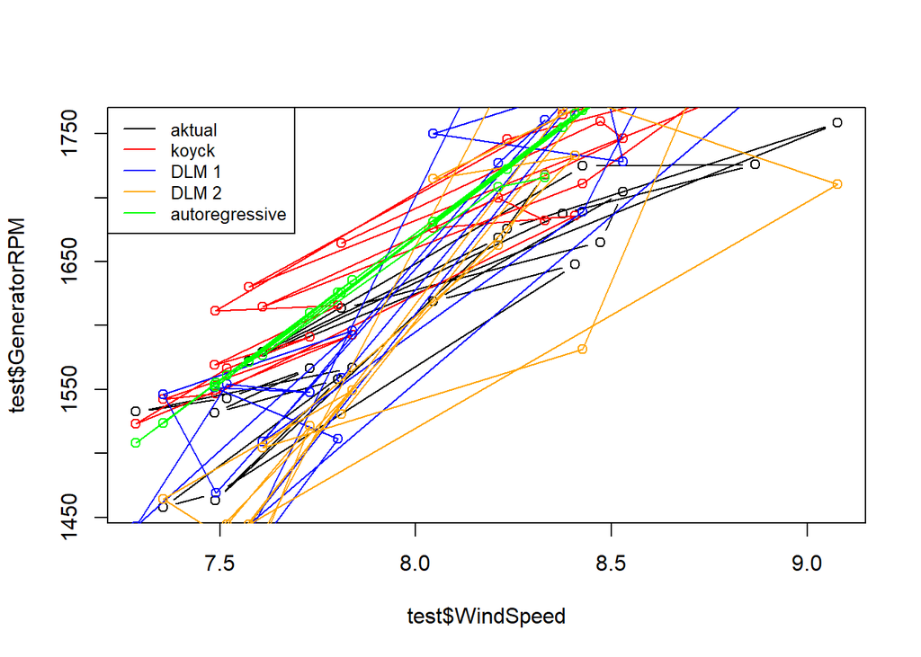

```r
par(mfrow=c(1,1))
plot(test$WindSpeed, test$GeneratorRPM, type="b", col="black")
points(test$WindSpeed, fore.koyck$forecasts,col="red")
lines(test$WindSpeed, fore.koyck$forecasts,col="red")
points(test$WindSpeed, fore.dlm$forecasts,col="blue")
lines(test$WindSpeed, fore.dlm$forecasts,col="blue")
points(test$WindSpeed, fore.dlm2$forecasts,col="orange")
lines(test$WindSpeed, fore.dlm2$forecasts,col="orange")
points(test$WindSpeed, fore.ardl$forecasts,col="green")
lines(test$WindSpeed, fore.ardl$forecasts,col="green")
legend("topleft",c("aktual", "koyck","DLM 1","DLM 2", "autoregressive"), lty=1, col=c("black","red","blue","orange","green"), cex=0.8)
```

Berdasarkan plot tersebut, terlihat bahwa plot yang paling mendekati data aktualnya adalah Model koyck, sehingga dapat disimpulkan model terbaik dalam hal ini adalah model regresi koyck.